# Density Estimation: Lecture Notes

06-12-2023

This file will be my first attempt to take notes via an `.Rmd` file. Today’s morning lecture for SURE 2023 is about density estimation.

# Building Intuition about Density Estimation

Bold idea: **mass of objects can be measured**

BUT many comparisons are not “like with like” because volumes vary

**Density = mass/volume** to the rescue!

Probability’s bold idea: **probability of events can be measured**

### How do we measure probability?

For continuous variables: probability density function

**Rules:**

- P(event) is between 0,1 (inclusive)
- Area under PDF integrates to 1 (like fixing the volume in density, directly comparable)

### The Idea on Estimation

The notion of inference:

- Samples are snapshots into population but we care about population-level questions

**So, we must make assumptions and estimations…**

- Must assume the event space follows some distribution
- Must assume the specific distribution that generates the data
- Must *estimate* the parameters for specific distribution

  *This estimation comes from statistical techniques*

# The Data

The data for today is about Steph Curry’s shots.

```r
curry_shots <-  read_csv("https://shorturl.at/xFI18")
head(curry_shots)
```

```
## # A tibble: 6 × 8
##   shot_x shot_y shot_distance is_shot_made period fg_type    shot_zone shot_type
##    <dbl>  <dbl>         <dbl> <lgl>         <dbl> <chr>      <chr>     <chr>
## 1   -109    260            28 FALSE             1 3PT Field… Above th… Pullup J…
## 2     48    257            26 FALSE             1 3PT Field… Above th… Running …
## 3   -165    189            25 TRUE              1 3PT Field… Above th… Jump Shot
## 4    -13     12             1 FALSE             1 2PT Field… Restrict… Driving …
## 5    -15     22             2 FALSE             1 2PT Field… Restrict… Layup Sh…
## 6     18     16             2 FALSE             1 2PT Field… Restrict… Driving …
```

# Histograms

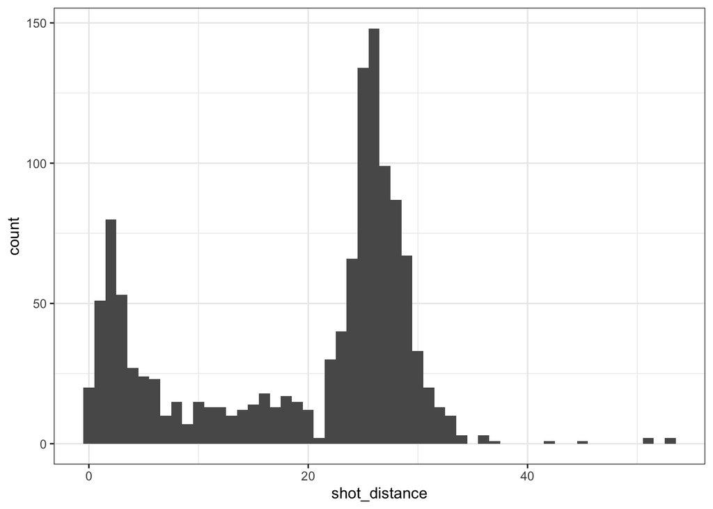

```r
curry_shots %>%
ggplot(aes(x = shot_distance)) +
geom_histogram(binwidth = 1) +
theme_bw()
```

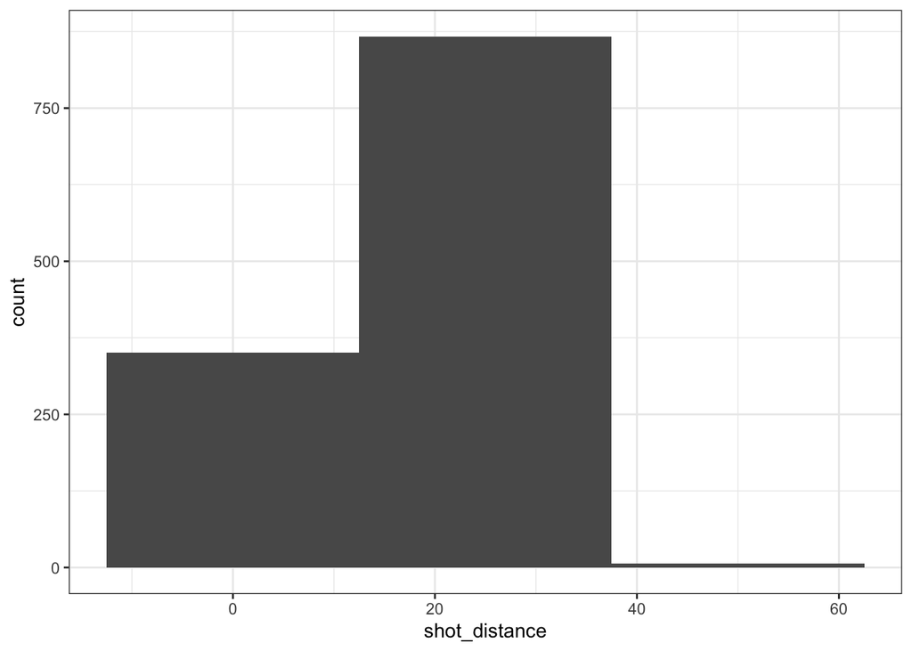

```r
curry_shots %>%
ggplot(aes(x = shot_distance)) +
geom_histogram(binwidth = 25) +
theme_bw()
```

## Subtle Point about Histogram Code

**By default:**

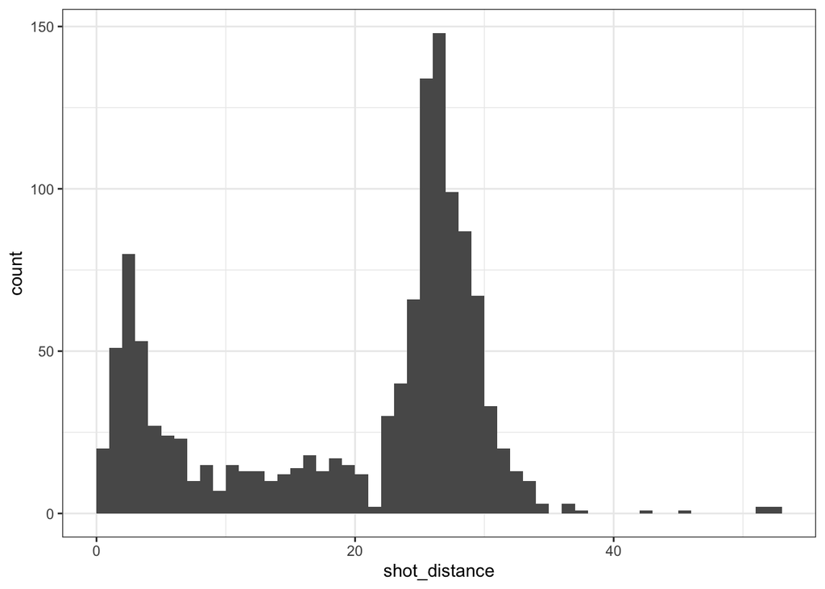

```r
curry_shots %>%
ggplot(aes(x = shot_distance)) +
geom_histogram(binwidth = 1, center = 0.5,
closed = "left") +
theme_bw()
```

*NOTE: Freedman-Diaconis Rule for bin width*

# Kernel Density Estimation

**GOAL:** estimate the PDF f(x) for all possible values (assuming it is continuous/smooth)

*Formula:*

$$\hat{f}(x) = \frac{1}{n}\sum_{i =
1}^{n}{K_h(x-x_i)}$$

*Kernel is a “continuous weighting of f” that satisfies:*

*(1) non-negative*

*(2) symmetric about 0*

*(3) goes to 0 as x goes to infinity or negative infinity*

**Other Notes:**

- n = sample size, x = new point estimate f(x) [does not have to be in the dataset!]
- h = bandwidth analogous to histogram bin width, ensures $\hat{f}(x)$ integrates to 1
- $x_i$ = *i*th observation in the data set
- $K_h(x - x_i)$ is the **Kernel** function, creates **weight** given distance of *i*th observation from new point
- As bandwidth (h) increases, weights are more evenly spread out (and as h decreases, more concentrated around x)
- typically use **Gaussian/Normal** kernel [can look up online]
- $K_h(x - x_i)$ is large when $x_i$ is close to x

**Histogram is basically a step-function version of Kernel Density Estimation**

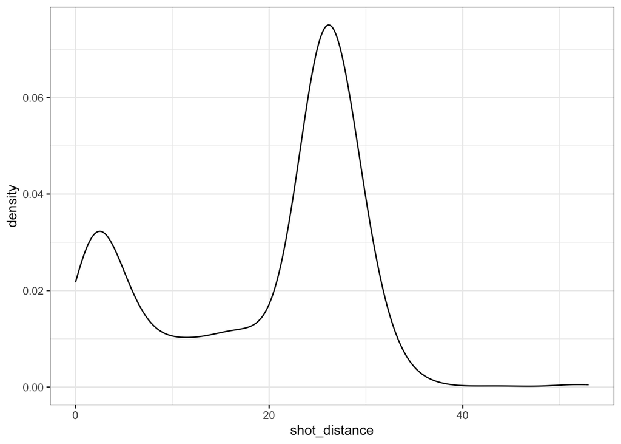

```r
curry_shots %>%
ggplot(aes(x = shot_distance)) +
geom_density() +
theme_bw()
```

## What about for 2D? (two continuous variables)

### Contours

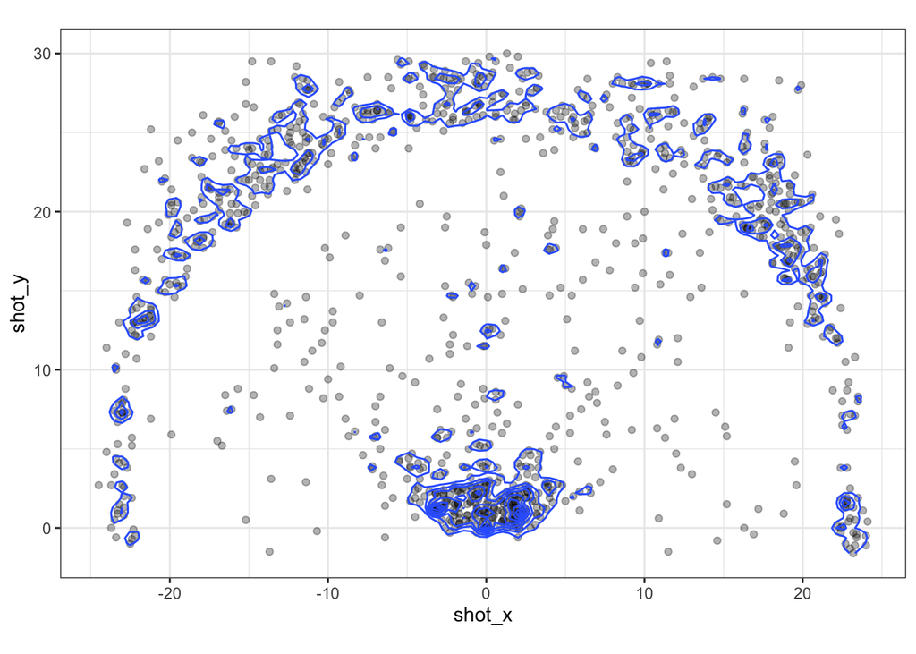

```r
curry_shots %>% # Modify the shot coordinates
  mutate(shot_x = -shot_x / 10, shot_y = shot_y / 10) %>%
  filter(shot_y <= 30) %>%
  ggplot(aes(x = shot_x, y = shot_y)) +
  geom_point(alpha = 0.3) +
   geom_density2d(adjust = 0.1) + #adds blue level sets for contours
  coord_fixed() +
  theme_bw()
```

### Heatmaps

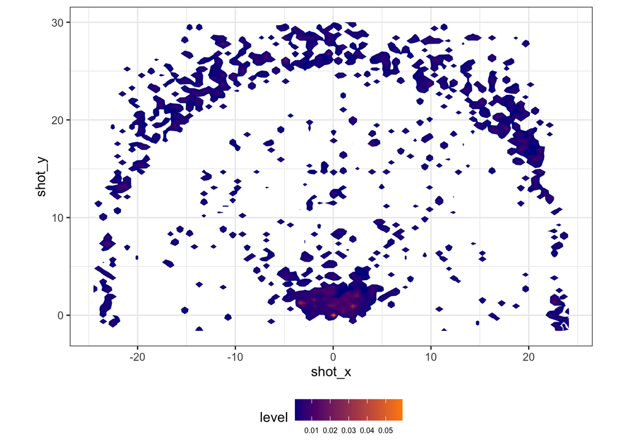

```r
curry_shots %>%  mutate(shot_x = -shot_x / 10, shot_y = shot_y / 10) %>%  filter(shot_y <= 30) %>%
ggplot(aes(x = shot_x, y = shot_y)) +
stat_density2d(h = 0.5, bins = 60, aes(fill = after_stat(level)),                 geom = "polygon") +
scale_fill_gradient(low = "darkblue", high = "darkorange") +
theme_bw() +
theme(legend.position = "bottom", legend.text = element_text(size = 6))+
  coord_fixed()
```